# Within Groups ANOVA with R

Let’s imagine you have participants answering the same question three times. Maybe the answer the question in September (Time 1), October (Time 2), or November (Time 3). Or maybe you have them taste test three flavors of ice cream during the same experimental session. Or, as with our class PPIR data, maybe you have participants answer the same question about three different groups of friends.

In cases like these, you have a within-groups design and a repeated measures ANOVA is appropriate.

This notebook will describe how to conduct a repeated measures ANOVA on this type of data.

First, we’ll download our class PPIR dataset.

```r
if (!require(foreign)){
  install.packages("foreign", dependencies = TRUE)
  require(foreign)
}
dataset = read.spss("https://osf.io/rbwvq/download", to.data.frame=TRUE, use.value.labels = FALSE)
```

```
/var/folders/3v/1ddc70sj14n6tzsm01wywfhmgc5nnh/T//RtmpBc4Tqj/file1267843b24fd0: Very long string record(s) found (record type 7, subtype 14), each will be imported in consecutive separate variables
```

```r
datasetNoIncompletes <- subset (x = dataset, dataset$Finished==1)
```

In this study, participants were asked whether they would report friends they felt high, medium, and low closeness with to the police. We want to know if those three conditions differ.

The first step is to create a data.frame() with our variables of interest. In this case, that will be the three dependent measures (how many times participants reported their high close friends to police: HCR1Count, how many times participants reported their medium close friends to police: MCR1Count, how many times participants reported their low close friends to police: LCR1Count, and an ID variable: ResponseID)

```r
myVariablesDF <- data.frame(datasetNoIncompletes$ResponseId, datasetNoIncompletes$HCR1Count, datasetNoIncompletes$MCR1Count, datasetNoIncompletes$LCR1Count)
#Rename the columns of the data.frame() so they make sense to us
colnames(myVariablesDF) = c("ResponseID", "High Close", "Medium Close", "Low Close")
```

If we look at this data.frame() we can see that it is in what R calls ‘wide format.’ Wide format is the way we normally think of a dataset. Each row refers to a specific participant and each column represents a variable. This is the format SPSS uses.

```r
head(myVariablesDF)
```

|  | ResponseID | High Close | Medium Close | Low Close |
| --- | --- | --- | --- | --- |
| 1 | R_12rnBm1rcjXFx1H | 0 | 2 | 3 |
| 2 | R_2AWFvpRB7LK5e6k | 2 | 2 | 1 |
| 3 | R_xFcO58PU8r7w0lX | 0 | 2 | 3 |
| 4 | R_3LX6h1jyLkdtw1b | 1 | 3 | 3 |
| 5 | R_1jcFAsz7hwOvRqa | 2 | 2 | 3 |
| 6 | R_24bAjffSDbbfUFn | 0 | 1 | 3 |

To conduct a repeated measures ANOVA in R, we need to convert this data.frame() into long format. In long format, the data for each participant is no longer on a single row. Instead, each participant will now have three rows–one row for each measurement of the dependent variable.

Let’s convert the myVariables data.frame() into long format and then take a look at it so you can see what I mean.

First, we’ll load the ‘reshape2’ package and then call the melt() command which does all the work of converting for us.

```r
if (!require(reshape2)){
  install.packages("reshape2", dependencies = TRUE)
  require(reshape2)
}
#Notice that we tell melt() which variable is the ID variable.
myVariablesDF.melt <- melt(myVariablesDF, id="ResponseID")
#Rename the columns of the melted data.frame() so they make sense to us
colnames(myVariablesDF.melt) = c("Participant", "Closeness", "TattleCount")
#Sort the myVariablesDF.melt data.frame() so we can get a better look at the 'long' format
myVariablesDF.melt[order(myVariablesDF.melt$Participant),]
```

|  | Participant | Closeness | TattleCount |
| --- | --- | --- | --- |
| 1 | R_12rnBm1rcjXFx1H | High Close | 0 |
| 67 | R_12rnBm1rcjXFx1H | Medium Close | 2 |
| 133 | R_12rnBm1rcjXFx1H | Low Close | 3 |
| 27 | R_1BRgZPa2UIFA5WH | High Close | 0 |
| 93 | R_1BRgZPa2UIFA5WH | Medium Close | 0 |
| 159 | R_1BRgZPa2UIFA5WH | Low Close | 0 |
| 66 | R_1C4v7zPWnCzxWi0 | High Close | 3 |
| 132 | R_1C4v7zPWnCzxWi0 | Medium Close | 3 |
| 198 | R_1C4v7zPWnCzxWi0 | Low Close | 3 |
| 20 | R_1dcNB1YTSoraBPu | High Close | 0 |

[output cut: 188 more lines]

```r
#look at the sorted data.frame()
head(myVariablesDF.melt)
```

|  | Participant | Closeness | TattleCount |
| --- | --- | --- | --- |
| 1 | R_12rnBm1rcjXFx1H | High Close | 0 |
| 2 | R_2AWFvpRB7LK5e6k | High Close | 2 |
| 3 | R_xFcO58PU8r7w0lX | High Close | 0 |
| 4 | R_3LX6h1jyLkdtw1b | High Close | 1 |
| 5 | R_1jcFAsz7hwOvRqa | High Close | 2 |
| 6 | R_24bAjffSDbbfUFn | High Close | 0 |

In the first table above, you can see the first three rows all refer to the same participant. We can see the first row refers to the number of times that participant reported their close friends to police. The second row refers to the number of times that participant reported their medium close friends to police. The third row refers to the number of times that participant reported their low close friends to the police.

With the data in ‘long’ format like this, we can tell R to conduct a repeated measures ANOVA. Here is the code for that:

```r
rm.anova <- aov(TattleCount ~ Closeness + Error(Participant/Closeness), data = myVariablesDF.melt)
```

aov is the name of the function that conducts ANOVAs in R. Inside the parentheses is information the aov command needs to conduct the ANOVA.

TattleCount is the DV.

Closenss is the IV.

Error () is how we tell aov() the proper error term to use. In this case, it is Participant/Closeness.

‘data =’ is how we tell aov() which data.frame() to use.

Here is how we see the results of the repeated measures ANOVA.

```r
summary(rm.anova)
```

```
Error: Participant
          Df Sum Sq Mean Sq F value Pr(>F)
Residuals 64  219.2   3.425

Error: Participant:Closeness
           Df Sum Sq Mean Sq F value   Pr(>F)
Closeness   2  30.07  15.036   32.48 3.91e-12 ***
Residuals 128  59.26   0.463
---
Signif. codes:  0 ‘***’ 0.001 ‘**’ 0.01 ‘*’ 0.05 ‘.’ 0.1 ‘ ’ 1
```

Check out the .rmd file to see how to use italics in R Markdown documents.

Here is how to interpret the results.

This is an F test.

The value of the F test is 32.48.

The degrees of freedom associated with the independent variable is 2.

Let’s visualize the data to get an idea of where the difference(s) might be. We’ll start by making a bar graph.

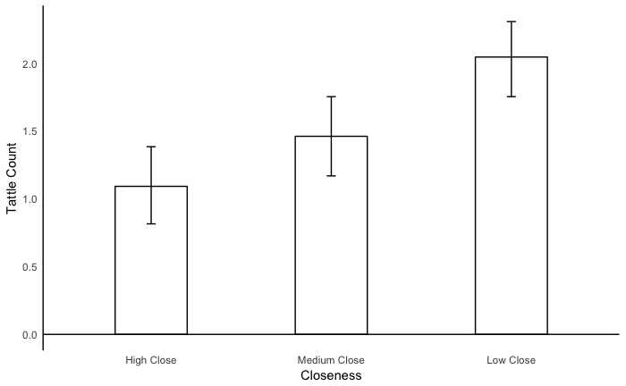

```r
if (!require(ggplot2)){
  install.packages("ggplot2", dependencies = TRUE)
  require(ggplot2)
}
if (!require(Hmisc)){
  install.packages("Hmisc", dependencies = TRUE)
  require(Hmisc)
}
ggplot(myVariablesDF.melt, aes(x = Closeness, y = TattleCount)) + stat_summary(fun.y="mean", geom="bar", width=.4, color="black", fill="white") + theme_minimal() + theme(panel.grid = element_blank(), axis.line.y = element_line(color="black", size = .5)) + geom_hline(yintercept=0, color="black", size=.5) + labs(x = "Closeness", y = "Tattle Count") + stat_summary(fun.data = "mean_cl_boot", geom="errorbar", width=.05)
```

It looks like the least amount of tattling happens with High close friends and the most amount of tattling happens with low close friends. Tattling on medium close friends is somewhere in the middle. Makes sense!